# Práctica 2: Evaluación de los Cultivos de Exportación Mexicanos para la Negociación del TMEC

2026-04-14

> **Contexto:** El T-MEC será renegociado en 2026. El equipo debe identificar qué productos agrícolas de exportación proteger, cuáles impulsar y cuáles presentan vulnerabilidades.

> **Datos:** Principales cultivos de exportación 2003–2024 (SIAP)  
> **Fuente:** https://nube.agricultura.gob.mx/cierre_agricola/

**Objetivos:**

- Dominar verbos centrales de `dplyr`: `filter`, `group_by`, `summarise`, `mutate`, `arrange`, `left_join`, `case_when`, `pivot_wider` / `pivot_longer`
- Graficar con `ggplot2`
- Crear mapas estáticos con `sf` + `ggplot2`
- Aprender a iterar con loops (`for`) para automatizar visualizaciones
- Crear GIFs

# 1 Configuración Inicial

## 1.1 Instalación de librerías

```r
install.packages(c("tidyr", "dplyr", "readxl", "ggplot2",
                   "RColorBrewer", "devtools", "gganimate", "gifski",
                   "sf", "scales", "stringi"))

# Para instalar ggradar (radar plot)
# devtools::install_github("ricardo-bion/ggradar")
```

## 1.2 Carga de librerías

```r
library(tidyr)
library(dplyr)
library(readxl)
library(ggplot2)
library(RColorBrewer)
library(ggradar)
library(gganimate)
library(gifski)
library(sf)
library(scales)
library(stringi)
```

## 1.3 Lectura de datos

```r
# Establecer directorio de trabajo
setwd("~/Documents/Cursos-R/Laboratorio-2")

# Leer el archivo Excel
data <- read_xlsx("cultivos.xlsx")

# Vistazo general
glimpse(data)
```

```
## Rows: 10,315
## Columns: 25
## $ origen             <chr> "Cierre_agricola_mun_2003", "Cierre_agricola_mun_20…
## $ Anio               <dbl> 2003, 2003, 2003, 2003, 2003, 2003, 2003, 2003, 200…
## $ Idestado           <dbl> 1, 1, 1, 2, 2, 2, 2, 3, 3, 3, 3, 3, 4, 4, 4, 4, 4, …
## $ Nomestado          <chr> "Aguascalientes", "Aguascalientes", "Aguascalientes…
## $ Idddr              <dbl> 1, 1, 1, 2, 2, 2, 3, 4, 4, 4, 5, 7, 8, 8, 9, 9, 9, …
## $ Nomddr             <chr> "Aguascalientes", "Aguascalientes", "Aguascalientes…
## $ Idcader            <dbl> 1, 1, 3, 3, 3, 3, 6, 1, 1, 2, 1, 1, 2, 2, 1, 1, 2, …
## $ Nomcader           <chr> "Aguascalientes", "Aguascalientes", "Pabellón", "En…
## $ Idmunicipio        <dbl> 11, 11, 9, 1, 1, 1, 2, 2, 2, 2, 1, 8, 8, 8, 2, 2, 6…
## $ Nommunicipio       <chr> "San Francisco de Los Romo", "San Francisco de Los …
## $ Idciclo            <dbl> 2, 2, 2, 2, 2, 3, 3, 1, 2, 1, 1, 3, 1, 1, 1, 3, 3, …
## $ Nomcicloproductivo <chr> "Primavera-Verano", "Primavera-Verano", "Primavera-…
## $ Idmodalidad        <dbl> 1, 1, 1, 1, 1, 1, 1, 1, 1, 1, 1, 1, 1, 1, 1, 1, 1, …
## $ Nommodalidad       <chr> "Riego", "Riego", "Riego", "Riego", "Riego", "Riego…
## $ Idunidadmedida     <dbl> 200201, 200201, 200201, 200201, 200201, 200201, 200…
## $ Nomunidad          <chr> "Tonelada", "Tonelada", "Tonelada", "Tonelada", "To…
## $ Idcultivo          <dbl> 5740000, 6120000, 6120000, 5940000, 8210000, 739000…
## $ Nomcultivo         <chr> "Calabacita", "Chile verde", "Chile verde", "Ceboll…
## $ Sembrada           <dbl> 29.00, 40.00, 24.00, 1710.00, 133.00, 80.00, 46.00,…
## $ Cosechada          <dbl> 29.00, 40.00, 24.00, 1710.00, 131.00, 72.00, 46.00,…
## $ Siniestrada        <dbl> 0, 0, 0, 0, 2, 0, 0, 0, 0, 2, 9, 0, 0, 0, 0, 0, 0, …
## $ Volumenproduccion  <dbl> 522.00, 288.00, 288.00, 52302.90, 5359.15, 372.24, …
## $ Rendimiento        <dbl> 18.00, 7.20, 12.00, 30.59, 40.91, 5.17, 20.50, 12.0…
## $ Precio             <dbl> 4069.00, 3595.10, 3000.00, 5158.19, 6136.89, 1974.8…
## $ Valorproduccion    <dbl> 2124018.0, 1035388.8, 864000.0, 269788409.3, 328884…
```

```r
# Observa la estructura
str(data)
```

```
## tibble [10,315 × 25] (S3: tbl_df/tbl/data.frame)
##  $ origen            : chr [1:10315] "Cierre_agricola_mun_2003" "Cierre_agricola_mun_2003" "Cierre_agricola_mun_2003" "Cierre_agricola_mun_2003" ...
##  $ Anio              : num [1:10315] 2003 2003 2003 2003 2003 ...
##  $ Idestado          : num [1:10315] 1 1 1 2 2 2 2 3 3 3 ...
##  $ Nomestado         : chr [1:10315] "Aguascalientes" "Aguascalientes" "Aguascalientes" "Baja California" ...
##  $ Idddr             : num [1:10315] 1 1 1 2 2 2 3 4 4 4 ...
##  $ Nomddr            : chr [1:10315] "Aguascalientes" "Aguascalientes" "Aguascalientes" "Ensenada" ...
##  $ Idcader           : num [1:10315] 1 1 3 3 3 3 6 1 1 2 ...
##  $ Nomcader          : chr [1:10315] "Aguascalientes" "Aguascalientes" "Pabellón" "Ensenada" ...
##  $ Idmunicipio       : num [1:10315] 11 11 9 1 1 1 2 2 2 2 ...
##  $ Nommunicipio      : chr [1:10315] "San Francisco de Los Romo" "San Francisco de Los Romo" "Tepezalá" "Ensenada" ...
##  $ Idciclo           : num [1:10315] 2 2 2 2 2 3 3 1 2 1 ...
##  $ Nomcicloproductivo: chr [1:10315] "Primavera-Verano" "Primavera-Verano" "Primavera-Verano" "Primavera-Verano" ...
##  $ Idmodalidad       : num [1:10315] 1 1 1 1 1 1 1 1 1 1 ...
##  $ Nommodalidad      : chr [1:10315] "Riego" "Riego" "Riego" "Riego" ...
##  $ Idunidadmedida    : num [1:10315] 2e+05 2e+05 2e+05 2e+05 2e+05 ...
##  $ Nomunidad         : chr [1:10315] "Tonelada" "Tonelada" "Tonelada" "Tonelada" ...
##  $ Idcultivo         : num [1:10315] 5740000 6120000 6120000 5940000 8210000 7390000 7390000 5940000 8970000 6120000 ...
##  $ Nomcultivo        : chr [1:10315] "Calabacita" "Chile verde" "Chile verde" "Cebolla" ...
##  $ Sembrada          : num [1:10315] 29 40 24 1710 133 80 46 0.5 8 14 ...
##  $ Cosechada         : num [1:10315] 29 40 24 1710 131 72 46 0.5 8 12 ...
##  $ Siniestrada       : num [1:10315] 0 0 0 0 2 0 0 0 0 2 ...
##  $ Volumenproduccion : num [1:10315] 522 288 288 52303 5359 ...
##  $ Rendimiento       : num [1:10315] 18 7.2 12 30.6 40.9 ...
##  $ Precio            : num [1:10315] 4069 3595 3000 5158 6137 ...
##  $ Valorproduccion   : num [1:10315] 2.12e+06 1.04e+06 8.64e+05 2.70e+08 3.29e+07 ...
```

```r
# Nombre de las columnas
colnames(data)
```

```
##  [1] "origen"             "Anio"               "Idestado"
##  [4] "Nomestado"          "Idddr"              "Nomddr"
##  [7] "Idcader"            "Nomcader"           "Idmunicipio"
## [10] "Nommunicipio"       "Idciclo"            "Nomcicloproductivo"
## [13] "Idmodalidad"        "Nommodalidad"       "Idunidadmedida"
## [16] "Nomunidad"          "Idcultivo"          "Nomcultivo"
## [19] "Sembrada"           "Cosechada"          "Siniestrada"
## [22] "Volumenproduccion"  "Rendimiento"        "Precio"
## [25] "Valorproduccion"
```

Las variables disponibles en la base son:

[output not shown]

```r
# Cultivos únicos en la base, ordenados alfabéticamente
sort(unique(data$Nomcultivo), decreasing = FALSE)
```

```
##  [1] "Aguacate"               "Arándano"               "Brócoli"
##  [4] "Calabacita"             "Cebolla"                "Chile verde"
##  [7] "Espárrago"              "Frambuesa"              "Fresa"
## [10] "Limón"                  "Mango"                  "Pepino"
## [13] "Tomate rojo (jitomate)" "Zarzamora"
```

# 2 Sección 1 — Diagnóstico Productivo

> **Preguntas:**  
> 1A. ¿Cuál es el volumen de producción para cada cultivo?  
> 1B. ¿Cuánto aporta cada cultivo en valor?  
> 1C. ¿Cuánto ocupa de superficie cada cultivo?  
> 1D. ¿Qué rendimiento tiene cada cultivo?  
> 1E. ¿Qué precio tiene cada cultivo?

```r
# Dataframe con participaciones acumuladas por cultivo
participacion <- data %>%
  group_by(Nomcultivo) %>%
  summarise(
    volumen_acumulado  = sum(Volumenproduccion, na.rm = TRUE),
    valor_acumulado    = sum(Valorproduccion,   na.rm = TRUE),
    sembrada_acumulada = sum(Sembrada,          na.rm = TRUE)
  ) %>%
  mutate(
    participacion_volumen  = round(volumen_acumulado  / sum(volumen_acumulado)  * 100, 2),
    participacion_valor    = round(valor_acumulado    / sum(valor_acumulado)    * 100, 2),
    participacion_sembrada = round(sembrada_acumulada / sum(sembrada_acumulada) * 100, 2)
  ) %>%
  arrange(desc(participacion_valor))

participacion
```

```
## # A tibble: 14 × 7
##    Nomcultivo             volumen_acumulado valor_acumulado sembrada_acumulada
##    <chr>                              <dbl>           <dbl>              <dbl>
##  1 Chile verde                     6634062.    51200329015.            274743.
##  2 Aguacate                        2378980.    39044237746.            248549.
##  3 Tomate rojo (jitomate)          3608551.    28573708687.             68800.
##  4 Limón                           4449211.    20454372613.            344027.
##  5 Fresa                         166599184.    13374055651.             16310.
##  6 Mango                           3141283.    12625261109.            328686.
##  7 Cebolla                         1982329.     8831561863.             65351.
##  8 Pepino                          1294626.     6615718223.             27410.
##  9 Frambuesa                        147621.     6308827661.              8714.
## 10 Espárrago                        167318.     6267944301.             24168
## 11 Zarzamora                        201659.     4819921477.             13749.
## 12 Brócoli                          746338.     3991657581.             49133.
## 13 Calabacita                       763518.     3709448726.             42209.
## 14 Arándano                          30974.     1388626426.              2315.
## # ℹ 3 more variables: participacion_volumen <dbl>, participacion_valor <dbl>,
## #   participacion_sembrada <dbl>
```

## 2.1 Gráfica 1A: Volumen de Producción

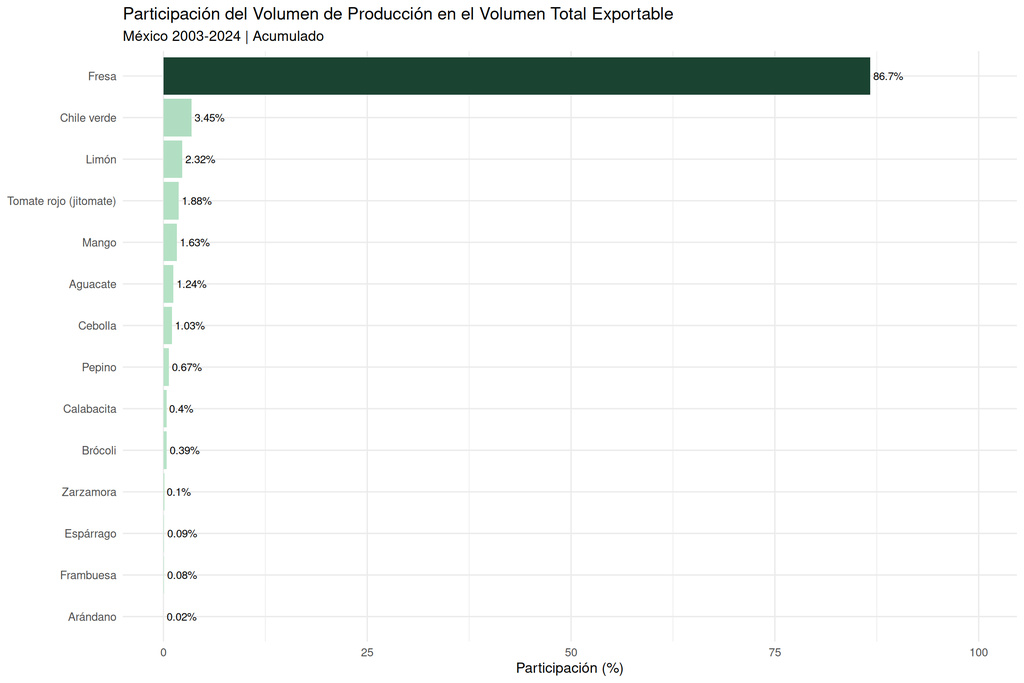

```r
participacion_volumen <- ggplot(participacion,
  aes(x = reorder(Nomcultivo, participacion_volumen),
      y = participacion_volumen,
      fill = participacion_volumen)) +
  geom_col(show.legend = FALSE) +
  geom_text(aes(label = paste0(participacion_volumen, "%")),
            hjust = -0.1, size = 3.2) +
  coord_flip() +
  scale_fill_gradient(low = "#b7e4c7", high = "#1b4332") +
  scale_y_continuous(limits = c(0, max(participacion$participacion_volumen) * 1.15)) +
  labs(
    title    = "Participación del Volumen de Producción en el Volumen Total Exportable",
    subtitle = "México 2003-2024 | Acumulado",
    x        = NULL,
    y        = "Participación (%)"
  ) +
  theme_minimal(base_size = 12)

ggsave("participacion_volumen.png", participacion_volumen, dpi = 300, width = 12, height = 10)
participacion_volumen
```

## 2.2 Gráfica 1B: Valor de Producción

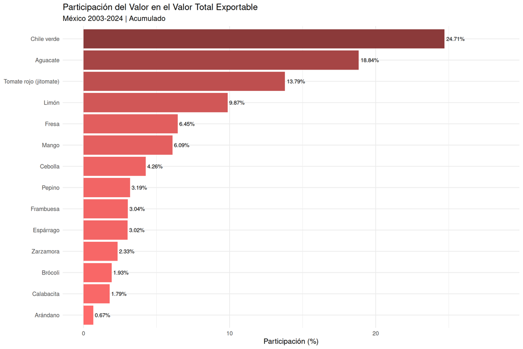

```r
participacion_valor <- ggplot(participacion,
  aes(x = reorder(Nomcultivo, participacion_valor),
      y = participacion_valor,
      fill = participacion_valor)) +
  geom_col(show.legend = FALSE) +
  geom_text(aes(label = paste0(participacion_valor, "%")),
            hjust = -0.1, size = 3.2) +
  coord_flip() +
  scale_fill_gradient(low = "indianred1", high = "indianred4") +
  scale_y_continuous(limits = c(0, max(participacion$participacion_valor) * 1.15)) +
  labs(
    title    = "Participación del Valor en el Valor Total Exportable",
    subtitle = "México 2003-2024 | Acumulado",
    x        = NULL,
    y        = "Participación (%)"
  ) +
  theme_minimal(base_size = 12)

ggsave("participacion_valor.png", participacion_valor, dpi = 300, width = 12, height = 10)
participacion_valor
```

## 2.3 Gráfica 1C: Superficie Sembrada

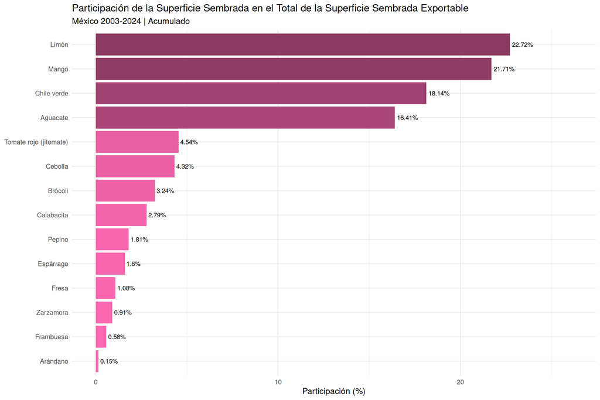

```r
participacion_sembrada <- ggplot(participacion,
  aes(x = reorder(Nomcultivo, participacion_sembrada),
      y = participacion_sembrada,
      fill = participacion_sembrada)) +
  geom_col(show.legend = FALSE) +
  geom_text(aes(label = paste0(participacion_sembrada, "%")),
            hjust = -0.1, size = 3.2) +
  coord_flip() +
  scale_fill_gradient(low = "hotpink", high = "hotpink4") +
  scale_y_continuous(limits = c(0, max(participacion$participacion_sembrada) * 1.15)) +
  labs(
    title    = "Participación de la Superficie Sembrada en el Total de la Superficie Sembrada Exportable",
    subtitle = "México 2003-2024 | Acumulado",
    x        = NULL,
    y        = "Participación (%)"
  ) +
  theme_minimal(base_size = 12)

ggsave("participacion_sembrada.png", participacion_sembrada, dpi = 300, width = 12, height = 10)
participacion_sembrada
```

## 2.4 Ejercicio 1

> **Ejercicio 1D:** ¿Qué rendimiento tiene cada cultivo?  
> **Ejercicio 1E:** ¿Qué precio tiene cada cultivo?

```r
# Tu código aquí
```

# 3 Sección 2 — Municipios y Estados por Cultivo

> **Preguntas:**  
> 2A. ¿Cuántos municipios producen cada cultivo?  
> 2B. ¿Cuántos estados producen cada cultivo?

```r
# Número de municipios por cultivo y año
municipios_cultivo <- data %>%
  group_by(Anio, Nomcultivo) %>%
  summarise(
    num_municipios = n_distinct(Nommunicipio),
    .groups = "drop"
  )

# Formato ancho (wide)
municipios_wide <- municipios_cultivo %>%
  pivot_wider(
    names_from  = Anio,
    values_from = num_municipios
  ) %>%
  arrange(Nomcultivo)

municipios_wide
```

```
## # A tibble: 14 × 23
##    Nomcultivo     `2003` `2004` `2005` `2006` `2007` `2008` `2009` `2010` `2011`
##    <chr>           <int>  <int>  <int>  <int>  <int>  <int>  <int>  <int>  <int>
##  1 Aguacate           43     34     36     24     32     35     31     28     32
##  2 Arándano           NA     NA     NA     NA      1     NA     NA     NA      1
##  3 Brócoli            14     14     14     12     10     11     18      9     15
##  4 Calabacita         48     55     44     52     40     44     40     52     48
##  5 Cebolla            23     27     35     33     28     29     30     33     31
##  6 Chile verde       130    129    126    105    114    117    119    105    121
##  7 Espárrago           2      3      2      3      3      2      1      3      2
##  8 Frambuesa          NA      2      4     NA      4     NA      3      2      2
##  9 Fresa              NA      1      6      7      7      5      5      5      2
## 10 Limón              33     44     41     45     49     40     46     52     44
## 11 Mango              31     35     47     30     29     34     39     40     51
## 12 Pepino             22     33     23     32     31     32     21     28     32
## 13 Tomate rojo (…     57     55     62     51     57     67     42     66     76
## 14 Zarzamora           2      2      3      4      5      5      6      5      5
## # ℹ 13 more variables: `2012` <int>, `2013` <int>, `2014` <int>, `2015` <int>,
## #   `2016` <int>, `2017` <int>, `2018` <int>, `2019` <int>, `2020` <int>,
## #   `2021` <int>, `2022` <int>, `2023` <int>, `2024` <int>
```

## 3.1 Gráfica 2A: Municipios Productores por Cultivo

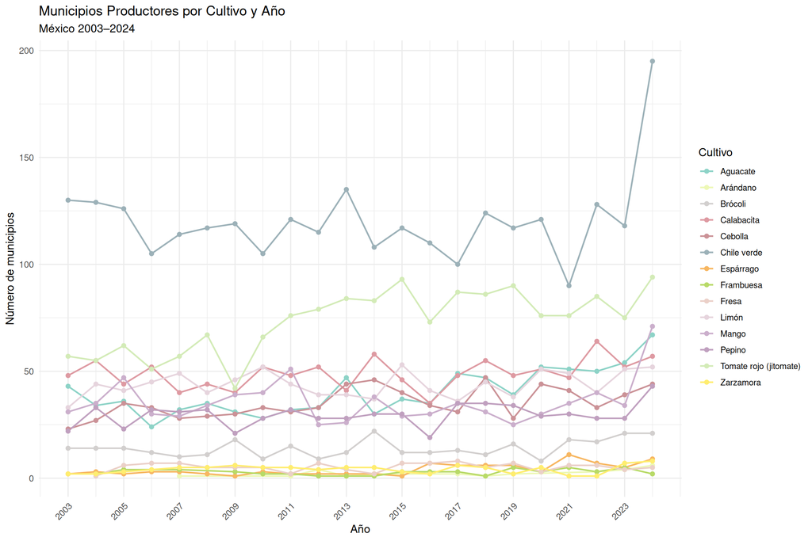

```r
municipios_plot <- ggplot(municipios_cultivo,
  aes(x = Anio, y = num_municipios,
      color = Nomcultivo, group = Nomcultivo)) +
  geom_line(linewidth = 0.8) +
  geom_point(size = 1.8) +
  scale_x_continuous(breaks = seq(2003, 2024, by = 2)) +
  scale_color_manual(values = colorRampPalette(
    RColorBrewer::brewer.pal(12, "Set3"))(14)) +
  labs(
    title    = "Municipios Productores por Cultivo y Año",
    subtitle = "México 2003–2024",
    x        = "Año",
    y        = "Número de municipios",
    color    = "Cultivo"
  ) +
  theme_minimal(base_size = 12) +
  theme(
    axis.text.x     = element_text(angle = 45, hjust = 1),
    legend.position = "right",
    legend.text     = element_text(size = 9)
  )

ggsave("municipios_por_cultivo.png", municipios_plot, dpi = 300, width = 14, height = 8)
municipios_plot
```

## 3.2 Gráfica 2A1: Participación de Municipios por Cultivo

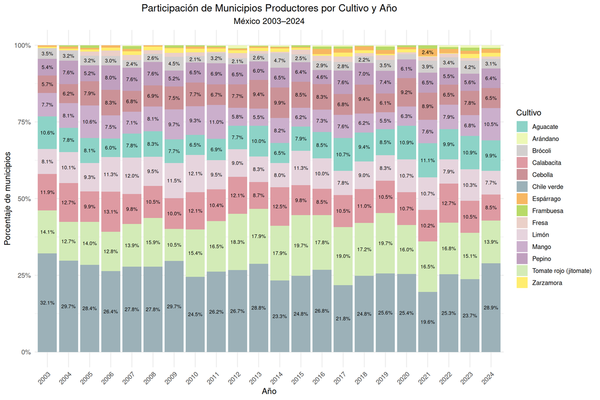

```r
# Calcular porcentajes
municipios_par_cultivo <- municipios_cultivo %>%
  group_by(Anio) %>%
  mutate(
    total_anio = sum(num_municipios, na.rm = TRUE),
    pct        = num_municipios / total_anio
  ) %>%
  ungroup() %>%
  arrange(Anio, desc(pct))

municipios_par_plot <- ggplot(
  municipios_par_cultivo %>%
    group_by(Anio) %>%
    arrange(desc(pct), .by_group = TRUE),
  aes(
    x    = factor(Anio),
    y    = pct,
    fill = Nomcultivo,
    group = interaction(Anio, reorder(Nomcultivo, pct))
  )
) +
  geom_bar(stat = "identity", position = "stack") +
  geom_text(
    aes(label = ifelse(pct > 0.02, scales::percent(pct, accuracy = 0.1), NA)),
    position = position_stack(vjust = 0.5),
    size = 2.5,
    na.rm = TRUE
  ) +
  scale_y_continuous(labels = scales::percent_format()) +
  scale_x_discrete(drop = FALSE) +
  scale_fill_manual(values = colorRampPalette(
    RColorBrewer::brewer.pal(12, "Set3"))(14)) +
  labs(
    title    = "Participación de Municipios Productores por Cultivo y Año",
    subtitle = "México 2003–2024",
    x        = "Año",
    y        = "Porcentaje de municipios",
    fill     = "Cultivo"
  ) +
  theme_minimal(base_size = 12) +
  theme(
    plot.title      = element_text(hjust = 0.5),
    plot.subtitle   = element_text(hjust = 0.5),
    axis.text.x     = element_text(angle = 45, hjust = 1),
    legend.position = "right",
    legend.text     = element_text(size = 9)
  )

ggsave("municipios_par_plot.png", municipios_par_plot, dpi = 300, width = 14, height = 8)
municipios_par_plot
```

## 3.3 Gráfica 2A2: Radar — Municipios Productores por Cultivo (GIF animado)

```r
# Transformar para radar
radar_data <- municipios_par_cultivo %>%
  select(Anio, Nomcultivo, pct) %>%
  pivot_wider(names_from = Nomcultivo, values_from = pct, values_fill = 0) %>%
  arrange(Anio)

radar_values <- radar_data %>%
  select(-Anio) %>%
  mutate(across(everything(), as.numeric))

radar_data_fixed <- radar_values
radar_data_fixed$group <- as.character(radar_data$Anio)
radar_data_fixed <- radar_data_fixed %>% select(group, everything())

# Paleta de colores
anios  <- as.numeric(radar_data$Anio)
colores <- colorRampPalette(brewer.pal(12, "Set3"))(length(anios))

# Crear frames del radar
dir.create("frames_radar", showWarnings = FALSE)
unlink(list.files("frames_radar", full.names = TRUE), recursive = FALSE)

for (i in seq_along(anios)) {
  anio_i  <- anios[i]
  datos_i <- radar_data_fixed %>% slice(i)

  p <- ggradar(
    datos_i,
    values.radar     = c("0%", "15%", "30%"),
    grid.min         = 0,
    grid.mid         = 0.15,
    grid.max         = 0.30,
    group.colours    = colores[i],
    group.line.width = 1.5,
    group.point.size = 3,
    axis.label.size  = 3,
    grid.label.size  = 4,
    legend.position  = "none",
    plot.title       = paste0("Municipios Productores por Cultivo\nMéxico — ", anio_i)
  ) +
    theme_minimal() +
    theme(
      plot.title      = element_text(hjust = 0.5, size = 10, face = "plain"),
      legend.position = "none"
    )

  ggsave(
    filename = file.path("frames_radar", sprintf("frame_%02d.png", i)),
    plot = p, width = 10, height = 8, dpi = 300
  )
}

# Generar GIF
frames <- list.files("frames_radar", full.names = TRUE, pattern = "frame_.*png")
gifski(
  png_files = frames,
  gif_file  = "radar_municipios.gif",
  width     = 1500,
  height    = 1200,
  delay     = 1.5
)
```

```
## [1] "/home/arimarhol/Documents/Cursos-R/Laboratorio-2/radar_municipios.gif"
```

```r
message("✓ GIF guardado: radar_municipios.gif")
```

## 3.4 Ejercicio 2

> **Ejercicio 2B:** Reproducir los análisis anteriores para los **estados**.

```r
# Tu código aquí
```

# 4 Sección 3 — Crecimiento con Escala Pseudo-log y Clasificación Granular

```r
primer_anio <- min(data$Anio, na.rm = TRUE)
ultimo_anio <- max(data$Anio, na.rm = TRUE)

# Mediana por cultivo
medianas <- data %>%
  group_by(Nomcultivo) %>%
  summarise(mediana_total = median(Valorproduccion, na.rm = TRUE), .groups = "drop")

# Crecimiento entre primer y último año
crecimiento_total <- data %>%
  filter(Anio %in% c(primer_anio, ultimo_anio)) %>%
  group_by(Nomcultivo, Anio) %>%
  summarise(produccion = mean(Valorproduccion, na.rm = TRUE), .groups = "drop") %>%
  pivot_wider(names_from = Anio, values_from = produccion, names_prefix = "anio_") %>%
  rename(
    produccion_inicial = !!sym(paste0("anio_", primer_anio)),
    produccion_final   = !!sym(paste0("anio_", ultimo_anio))
  ) %>%
  left_join(medianas, by = "Nomcultivo") %>%
  mutate(
    produccion_inicial = if_else(is.na(produccion_inicial), mediana_total, produccion_inicial),
    produccion_final   = if_else(is.na(produccion_final),   mediana_total, produccion_final),
    crecimiento_pct    = (produccion_final / produccion_inicial - 1) * 100
  ) %>%
  filter(produccion_inicial > 0, is.finite(crecimiento_pct)) %>%
  select(-mediana_total)
```

```r
# Siete clasificaciones de crecimiento
crecimiento_total <- crecimiento_total %>%
  mutate(
    clasificacion = case_when(
      crecimiento_pct >= 1000  ~ "Crecimiento explosivo (≥1000%)",
      crecimiento_pct >= 200   ~ "Crecimiento muy alto (200-999%)",
      crecimiento_pct >= 50    ~ "Crecimiento alto (50-199%)",
      crecimiento_pct >= 10    ~ "Crecimiento moderado (10-49%)",
      crecimiento_pct >= 0     ~ "Crecimiento leve (0-9%)",
      crecimiento_pct >= -20   ~ "Declive leve (-20% a -0.1%)",
      TRUE                     ~ "Declive severo (< -20%)"
    )
  )

# Orden de categorías
orden_categorias <- c(
  "Crecimiento explosivo (≥1000%)",
  "Crecimiento muy alto (200-999%)",
  "Crecimiento alto (50-199%)",
  "Crecimiento moderado (10-49%)",
  "Crecimiento leve (0-9%)",
  "Declive leve (-20% a -0.1%)",
  "Declive severo (< -20%)"
)
crecimiento_total$clasificacion <- factor(crecimiento_total$clasificacion, levels = orden_categorias)

# Paleta de colores
colores_categorias <- c(
  "Crecimiento explosivo (≥1000%)"  = "#00441B",
  "Crecimiento muy alto (200-999%)" = "#006D2C",
  "Crecimiento alto (50-199%)"      = "#238B45",
  "Crecimiento moderado (10-49%)"   = "#66C2A4",
  "Crecimiento leve (0-9%)"         = "#BAE4B3",
  "Declive leve (-20% a -0.1%)"     = "#FCAE91",
  "Declive severo (< -20%)"         = "#CB181D"
)
```

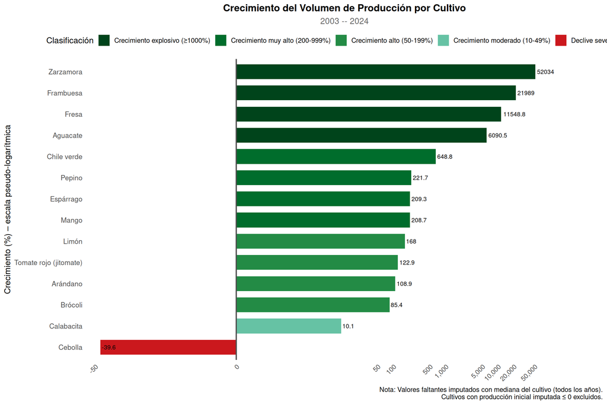

```r
crecimiento_plot <- ggplot(crecimiento_total,
  aes(x    = reorder(Nomcultivo, crecimiento_pct),
      y    = crecimiento_pct,
      fill = clasificacion)) +
  geom_col(width = 0.7) +
  geom_hline(yintercept = 0, linetype = "solid", color = "gray30", linewidth = 0.8) +
  geom_text(aes(label = round(crecimiento_pct, 1)),
            hjust = -0.1, size = 3, color = "black") +
  coord_flip() +
  scale_y_continuous(
    trans  = pseudo_log_trans(sigma = 0.1),
    breaks = c(-50, 0, 50, 100, 500, 1000, 5000, 10000, 20000, 50000),
    labels = comma_format(accuracy = 1),
    limits = c(-50, 55000),
    expand = expansion(mult = c(0.02, 0.15))
  ) +
  scale_fill_manual(values = colores_categorias, name = "Clasificación") +
  labs(
    title    = "Crecimiento del Volumen de Producción por Cultivo",
    subtitle = paste(primer_anio, "--", ultimo_anio),
    x        = "Crecimiento (%) – escala pseudo‑logarítmica",
    y        = NULL,
    caption  = "Nota: Valores faltantes imputados con mediana del cultivo (todos los años).\nCultivos con producción inicial imputada ≤ 0 excluidos."
  ) +
  theme_minimal(base_size = 12) +
  theme(
    plot.title    = element_text(face = "bold", size = 14, hjust = 0.5),
    plot.subtitle = element_text(color = "gray40", hjust = 0.5),
    axis.text.y   = element_text(size = 10),
    axis.text.x   = element_text(angle = 45, hjust = 1, vjust = 1),
    legend.position = "top",
    legend.box    = "vertical",
    panel.grid    = element_blank()
  )

ggsave("crecimiento_final.png", crecimiento_plot, dpi = 300, width = 14, height = 10)
crecimiento_plot
```

## 4.2 Ejercicio 3

```r
# Tu código aquí
```

# 5 Sección 4 — Mapas de Producción por Cultivo y Estado

## 5.1 Preparación: Cargar y estandarizar el Shapefile

```r
# Leer shapefile (los archivos .shp, .dbf, .shx y .prj deben estar en la misma carpeta)
estados_sf <- st_read("00ent.shp")
glimpse(estados_sf)
```

```
## Rows: 32
## Columns: 4
## $ CVEGEO   <chr> "01", "02", "03", "04", "05", "06", "07", "08", "09", "10", "…
## $ CVE_ENT  <chr> "01", "02", "03", "04", "05", "06", "07", "08", "09", "10", "…
## $ NOMGEO   <chr> "Aguascalientes", "Baja California", "Baja California Sur", "…
## $ geometry <MULTIPOLYGON [m]> MULTIPOLYGON (((2469551 115..., MULTIPOLYGON (((…
```

```r
# Estandarizar nombres de entidades federativas en la base de datos
data <- data %>%
  mutate(Nomestado = case_when(
    Nomestado %in% c("Michoacán", "Michoacán de Ocampo")                            ~ "Michoacán de Ocampo",
    Nomestado %in% c("Ciudad de México / DF", "Ciudad de México")                   ~ "Ciudad de México",
    Nomestado %in% c("Coahuila", "Coahuila de Zaragoza")                            ~ "Coahuila de Zaragoza",
    Nomestado %in% c("Veracruz", "Veracruz de Ignacio de la Llave")                 ~ "Veracruz de Ignacio de la Llave",
    TRUE ~ Nomestado
  ))

# Quitar acentos y convertir a mayúsculas para el join (Shapefile)
estados_sf <- estados_sf %>%
  mutate(
    nom_join = stri_trans_general(NOMGEO, "Latin-ASCII") %>%
      toupper() %>%
      trimws()
  )

# Replicar para el dataframe
data <- data %>%
  mutate(
    nom_join = stri_trans_general(Nomestado, "Latin-ASCII") %>%
      toupper() %>%
      trimws()
  )
```

## 5.2 Gráfica 4A: Mapa de Producción Total por Estado (2024)

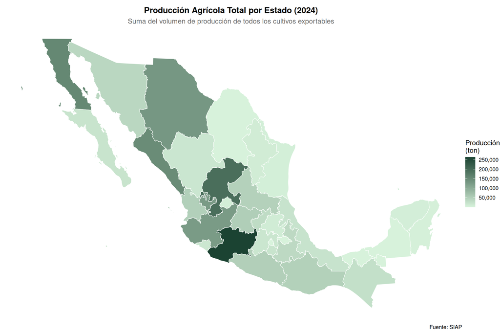

```r
prod_estado_2024 <- data %>%
  filter(Anio == 2024) %>%
  group_by(nom_join) %>%
  summarise(
    produccion_total = sum(Volumenproduccion, na.rm = TRUE),
    valor_total      = sum(Valorproduccion,   na.rm = TRUE),
    .groups = "drop"
  )

mapa_total <- estados_sf %>%
  left_join(prod_estado_2024, by = "nom_join")

mapa_prod_total <- ggplot(mapa_total) +
  geom_sf(aes(fill = produccion_total), color = "white", linewidth = 0.3) +
  scale_fill_gradient(
    low      = "#d8f3dc",
    high     = "#1b4332",
    na.value = "gray90",
    name     = "Producción\n(ton)",
    labels   = comma
  ) +
  labs(
    title    = "Producción Agrícola Total por Estado (2024)",
    subtitle = "Suma del volumen de producción de todos los cultivos exportables",
    caption  = "Fuente: SIAP"
  ) +
  theme_void(base_size = 12) +
  theme(
    plot.title      = element_text(face = "bold", hjust = 0.5),
    plot.subtitle   = element_text(hjust = 0.5, color = "gray40"),
    legend.position = "right"
  )

ggsave("mapa_produccion_total_2024.png", mapa_prod_total, dpi = 300, width = 12, height = 8)
mapa_prod_total
```

> **Ejercicio 4A:** Reproducir para el **valor de la producción**.

## 5.3 Gráfica 4B: Mapa Facet por Cultivo (2024)

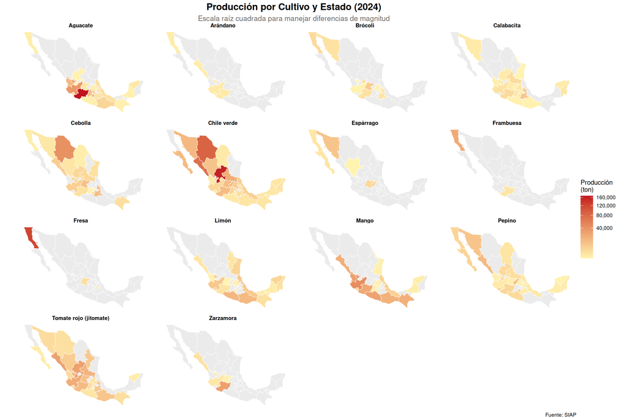

```r
prod_estado_cultivo <- data %>%
  filter(Anio == 2024) %>%
  group_by(nom_join, Nomcultivo) %>%
  summarise(
    produccion = sum(Volumenproduccion, na.rm = TRUE),
    valor      = sum(Valorproduccion,   na.rm = TRUE),
    .groups    = "drop"
  )

# cross_join para que estados sin cultivo aparezcan en gris (NA)
mapa_cultivos <- estados_sf %>%
  cross_join(tibble(Nomcultivo = unique(prod_estado_cultivo$Nomcultivo))) %>%
  left_join(prod_estado_cultivo, by = c("nom_join", "Nomcultivo"))

mapa_facet <- ggplot(mapa_cultivos) +
  geom_sf(aes(fill = produccion), color = "white", linewidth = 0.15) +
  scale_fill_gradient(
    low      = "#fff3b0",
    high     = "#c1121f",
    na.value = "gray92",
    name     = "Producción\n(ton)",
    labels   = comma,
    trans    = "sqrt"  # escala raíz cuadrada para suavizar outliers
  ) +
  facet_wrap(~ Nomcultivo, ncol = 4) +
  labs(
    title    = "Producción por Cultivo y Estado (2024)",
    subtitle = "Escala raíz cuadrada para manejar diferencias de magnitud",
    caption  = "Fuente: SIAP"
  ) +
  theme_void(base_size = 9) +
  theme(
    plot.title    = element_text(face = "bold", hjust = 0.5, size = 13),
    plot.subtitle = element_text(hjust = 0.5, color = "gray40", size = 10),
    strip.text    = element_text(face = "bold", size = 7.5),
    legend.position = "right"
  )

ggsave("mapa_cultivos_facet_2024.png", mapa_facet, dpi = 300, width = 20, height = 18)
mapa_facet
```

> **Ejercicio 4B:** Reproducir para el **valor de la producción**.

## 5.4 Gráfica 4C: Estados Líderes por Número de Cultivos (2020–2024)

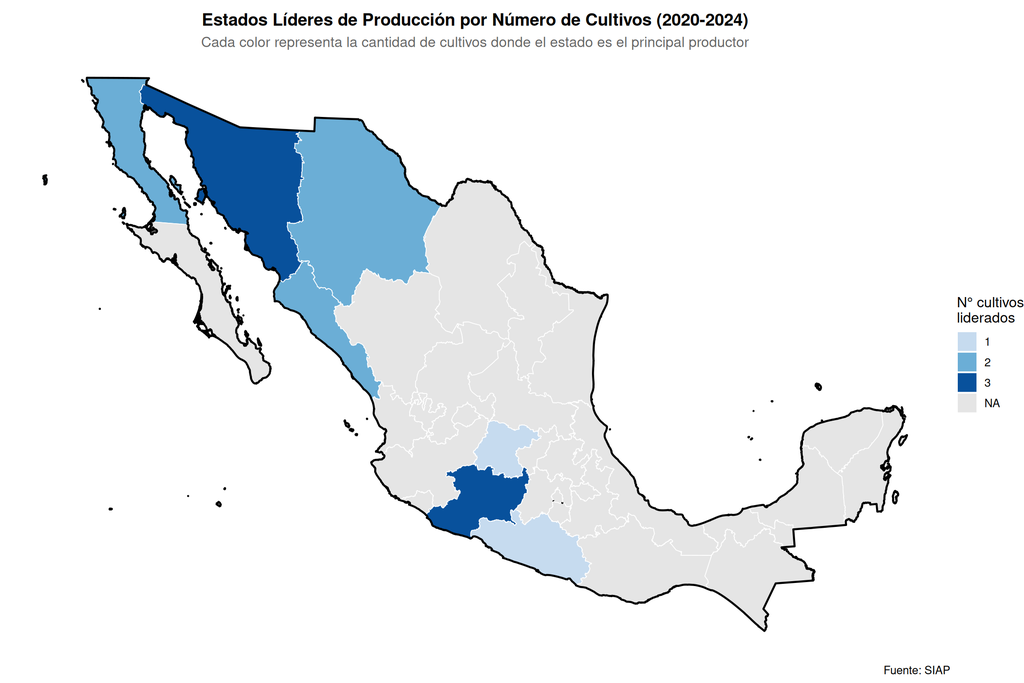

```r
# Estado con mayor producción por cultivo (2020-2024)
estado_lider <- data %>%
  filter(Anio >= 2020) %>%
  group_by(Nomcultivo, nom_join) %>%
  summarise(produccion = sum(Valorproduccion, na.rm = TRUE), .groups = "drop") %>%
  group_by(Nomcultivo) %>%
  slice_max(produccion, n = 1, with_ties = FALSE) %>%
  ungroup()

liderazgo_estado <- estado_lider %>%
  group_by(nom_join) %>%
  summarise(
    cultivos_liderados = n(),
    cultivos           = paste(Nomcultivo, collapse = "\n"),
    .groups = "drop"
  )

mapa_liderazgo <- estados_sf %>%
  left_join(liderazgo_estado, by = "nom_join") %>%
  mutate(cultivos_liderados = factor(cultivos_liderados, levels = c("1", "2", "3")))

colores_discretos <- c(
  "1" = "#c6dbef",
  "2" = "#6baed6",
  "3" = "#08519c"
)

contorno_nacional <- estados_sf %>%
  st_union() %>%
  st_boundary()

mapa_lider_plot <- ggplot() +
  geom_sf(data = mapa_liderazgo,
          aes(fill = cultivos_liderados),
          color = "white", linewidth = 0.3) +
  geom_sf(data = contorno_nacional,
          color = "black", linewidth = 0.8, fill = NA) +
  scale_fill_manual(
    values   = colores_discretos,
    na.value = "gray90",
    name     = "N° cultivos\nliderados"
  ) +
  labs(
    title    = "Estados Líderes de Producción por Número de Cultivos (2020-2024)",
    subtitle = "Cada color representa la cantidad de cultivos donde el estado es el principal productor",
    caption  = "Fuente: SIAP"
  ) +
  theme_void(base_size = 12) +
  theme(
    plot.title    = element_text(face = "bold", hjust = 0.5),
    plot.subtitle = element_text(hjust = 0.5, color = "gray40"),
    legend.position = "right"
  )

ggsave("mapa_liderazgo_estados.png", mapa_lider_plot, dpi = 300, width = 12, height = 8)
mapa_lider_plot
```

# 6 Sección 5 — Mapas Animados y Loop Facet

## 6.1 Configuración inicial

```r
# Crear carpetas de salida
dir.create("mapas_anuales",          showWarnings = FALSE)
dir.create("mapas_anuales/total",    showWarnings = FALSE)
dir.create("mapas_anuales/facet",    showWarnings = FALSE)
dir.create("mapas_anuales/por_cultivo", showWarnings = FALSE)

anios         <- sort(unique(data$Anio))
cultivos_lista <- sort(unique(data$Nomcultivo))

# Rangos fijos para escalas consistentes
rango_total <- data %>%
  group_by(Anio, nom_join) %>%
  summarise(prod = sum(Volumenproduccion, na.rm = TRUE), .groups = "drop") %>%
  summarise(min = min(prod, na.rm = TRUE), max = max(prod, na.rm = TRUE))

rango_cultivos <- data %>%
  group_by(Nomcultivo, nom_join, Anio) %>%
  summarise(prod = sum(Volumenproduccion, na.rm = TRUE), .groups = "drop") %>%
  group_by(Nomcultivo) %>%
  summarise(max_prod = max(prod, na.rm = TRUE), .groups = "drop")
```

## 6.2 5A — Loop: Mapa Total por Año → GIF

```r
for (anio_i in anios) {
  datos_anio <- data %>%
    filter(Anio == anio_i) %>%
    group_by(nom_join) %>%
    summarise(produccion_total = sum(Volumenproduccion, na.rm = TRUE), .groups = "drop")

  mapa_i <- estados_sf %>%
    left_join(datos_anio, by = "nom_join")

  p <- ggplot(mapa_i) +
    geom_sf(aes(fill = produccion_total), color = "white", linewidth = 0.3) +
    scale_fill_viridis_c(
      name     = "Producción\n(ton)",
      labels   = comma,
      na.value = "gray90",
      option   = "viridis"
    ) +
    labs(
      title    = paste("Producción Agrícola Total por Estado —", anio_i),
      subtitle = "Suma de todos los cultivos exportables | Escala viridis flexible",
      caption  = "Fuente: SIAP"
    ) +
    theme_void(base_size = 12) +
    theme(
      plot.title       = element_text(face = "bold", hjust = 0.5),
      plot.subtitle    = element_text(hjust = 0.5, color = "gray40"),
      legend.position  = "right",
      legend.key.width  = unit(1.2, "cm"),
      legend.key.height = unit(1.5, "cm"),
      legend.text      = element_text(size = 10),
      legend.title     = element_text(size = 11)
    )

  ggsave(sprintf("mapas_anuales/total/mapa_total_%d.png", anio_i),
         p, dpi = 150, width = 12, height = 8)
  message(sprintf("  Guardado: mapa_total_%d.png", anio_i))
}
message("✅ Loop 5A completado")

# Convertir a GIF
carpeta  <- "mapas_anuales/total/"
archivos <- list.files(carpeta, pattern = "mapa_total_.*\\.png$", full.names = TRUE)
anios_ord <- as.numeric(gsub(".*mapa_total_([0-9]+)\\.png", "\\1", basename(archivos)))
archivos  <- archivos[order(anios_ord)]

gifski(
  png_files = archivos,
  gif_file  = "produccion_total_animado.gif",
  width     = 900,
  height    = 600,
  delay     = 0.5
)
```

```
## [1] "/home/arimarhol/Documents/Cursos-R/Laboratorio-2/produccion_total_animado.gif"
```

```r
message("✅ GIF creado: produccion_total_animado.gif")
```

> **Ejercicio 5A:** Reproducir para el **valor de la producción**.

## 6.3 5B — Loop: Mapa Facet por Año → GIF

```r
for (anio_i in anios) {
  datos_anio_cultivo <- data %>%
    filter(Anio == anio_i) %>%
    group_by(nom_join, Nomcultivo) %>%
    summarise(produccion = sum(Volumenproduccion, na.rm = TRUE), .groups = "drop")

  cultivos_anio <- unique(datos_anio_cultivo$Nomcultivo)
  mapa_facet_i  <- estados_sf %>%
    cross_join(tibble(Nomcultivo = cultivos_anio)) %>%
    left_join(datos_anio_cultivo, by = c("nom_join", "Nomcultivo"))

  p <- ggplot(mapa_facet_i) +
    geom_sf(aes(fill = produccion), color = "white", linewidth = 0.2) +
    scale_fill_viridis_c(
      name     = "Producción\n(ton)",
      labels   = comma,
      option   = "viridis",
      na.value = "gray95"
    ) +
    facet_wrap(~ Nomcultivo, ncol = 4) +
    labs(
      title    = paste("Distribución Geográfica de Cultivos por Estado —", anio_i),
      subtitle = "Cada panel representa un cultivo | Escala viridis (flexible)",
      caption  = "Fuente: SIAP"
    ) +
    theme_void(base_size = 9) +
    theme(
      plot.title       = element_text(face = "bold", hjust = 0.5, size = 12),
      plot.subtitle    = element_text(hjust = 0.5, color = "gray40", size = 9),
      strip.text       = element_text(face = "bold", size = 7),
      legend.position  = "bottom",
      legend.key.width  = unit(1.5, "cm"),
      legend.key.height = unit(0.5, "cm"),
      legend.text      = element_text(size = 10),
      legend.title     = element_text(size = 11)
    )

  ggsave(sprintf("mapas_anuales/facet/mapa_facet_%d.png", anio_i),
         p, dpi = 150, width = 14, height = 12)
  message(sprintf("  Guardado: mapa_facet_%d.png", anio_i))
}

# Convertir a GIF
carpeta  <- "mapas_anuales/facet/"
archivos <- list.files(carpeta, pattern = "mapa_facet_.*\\.png$", full.names = TRUE)
anios_ord <- as.numeric(gsub(".*mapa_facet_([0-9]+)\\.png", "\\1", basename(archivos)))
archivos  <- archivos[order(anios_ord)]

gifski(
  png_files = archivos,
  gif_file  = "mapa_facet_animado.gif",
  width     = 1000,
  height    = 800,
  delay     = 0.8
)
```

```
## [1] "mapa_facet_animado.gif"
```

```r
message("✅ GIF creado: mapa_facet_animado.gif")
```

> **Ejercicio 5B:** Reproducir para el **valor de la producción**.

## 6.4 5C — Loop: Mapa por Cultivo Individual → GIF

```r
anios_por_imagen <- 6
grupos_anios     <- split(anios, ceiling(seq_along(anios) / anios_por_imagen))

for (cultivo_i in cultivos_lista) {
  datos_cultivo <- data %>%
    filter(Nomcultivo == cultivo_i) %>%
    group_by(nom_join, Anio) %>%
    summarise(produccion = sum(Volumenproduccion, na.rm = TRUE), .groups = "drop")

  for (g in seq_along(grupos_anios)) {
    anios_grupo  <- grupos_anios[[g]]
    rango_grupo  <- range(anios_grupo)
    datos_grupo  <- datos_cultivo %>% filter(Anio %in% anios_grupo)

    mapa_cultivo_grupo <- estados_sf %>%
      cross_join(tibble(Anio = anios_grupo)) %>%
      left_join(datos_grupo, by = c("nom_join", "Anio"))

    p <- ggplot(mapa_cultivo_grupo) +
      geom_sf(aes(fill = produccion), color = "white", linewidth = 0.15) +
      scale_fill_viridis_c(
        name     = "Producción\n(ton)",
        labels   = comma,
        na.value = "gray92",
        option   = "viridis"
      ) +
      facet_wrap(~ Anio, ncol = 3) +
      labs(
        title    = paste("Evolución Geográfica de la Producción —", cultivo_i),
        subtitle = paste(rango_grupo[1], "-", rango_grupo[2],
                         "| Escala viridis flexible | Máx. 6 años por imagen"),
        caption  = "Fuente: SIAP"
      ) +
      theme_void(base_size = 10) +
      theme(
        plot.title       = element_text(face = "bold", hjust = 0.5, size = 14),
        plot.subtitle    = element_text(hjust = 0.5, color = "gray40", size = 10),
        strip.text       = element_text(face = "bold", size = 9),
        legend.position  = "bottom",
        legend.key.width  = unit(1.8, "cm"),
        legend.key.height = unit(0.6, "cm"),
        legend.text      = element_text(size = 11),
        legend.title     = element_text(size = 12)
      )

    nombre_limpio  <- gsub("[^a-zA-Z0-9]", "_", tolower(cultivo_i))
    nombre_archivo <- sprintf("mapas_anuales/por_cultivo/evolucion_%s_%d_%d.png",
                              nombre_limpio, min(anios_grupo), max(anios_grupo))

    ggsave(nombre_archivo, p, dpi = 150, width = 12, height = 10)
    message(sprintf("  Guardado: %s [%s, años %d-%d]",
                    nombre_archivo, cultivo_i, min(anios_grupo), max(anios_grupo)))
  }
}
message("✅ Loop 5C completado: mapas por cultivo divididos en grupos de años")

# Crear un GIF por cultivo
carpeta_cultivos <- "mapas_anuales/por_cultivo/"
todos_archivos   <- list.files(carpeta_cultivos, pattern = "evolucion_.*\\.png$", full.names = TRUE)
cultivos_lista_gif <- unique(gsub("evolucion_([^_]+)_.*", "\\1", basename(todos_archivos)))

for (cultivo in cultivos_lista_gif) {
  archivos_cultivo <- todos_archivos[grepl(sprintf("evolucion_%s_", cultivo), basename(todos_archivos))]
  anios_inicio     <- as.numeric(gsub(sprintf("evolucion_%s_([0-9]+)_[0-9]+\\.png", cultivo), "\\1", basename(archivos_cultivo)))
  archivos_cultivo <- archivos_cultivo[order(anios_inicio)]

  gifski(
    png_files = archivos_cultivo,
    gif_file  = sprintf("mapas_anuales/por_cultivo/%s_evolucion_completa.gif", cultivo),
    width     = 800,
    height    = 700,
    delay     = 1.2
  )
  message(sprintf("✅ GIF creado para cultivo: %s", cultivo))
}

message("🎉 Todos los GIFs por cultivo han sido generados.")
```

> **Ejercicio 5C:** Reproducir para el **valor de la producción**.

*Fin de la Práctica 2*